# Exponential Growth COVID 19 in Switzerland

Andre Meichtry

2020-04-27

*The greatest shortcoming of the human race is the inability to understand the exponential function. (Al Bartlett)*

# 1 Problem

Sie sitzen zuoberst in einem Fussball-Stadion; es hat Platz für $6\times 10^{13}$ Wassertropfen. Es beginnt mit einem Tropfen, der in der ersten Minute ins Stadion tröpfelt. Jede Minute *verdoppelt* sich die Anzahl Tropfen. Lange passiert nichts Besonderes. Sie sehen die Gefahr nicht kommen. Von der *Hälfte* bis *ganz* oben geht es plötzlich sehr schnell. Es würde auch nicht viel bringen, wenn das Stadion noch viel grösser wäre; wir haben **exponentielles Wachstum**.

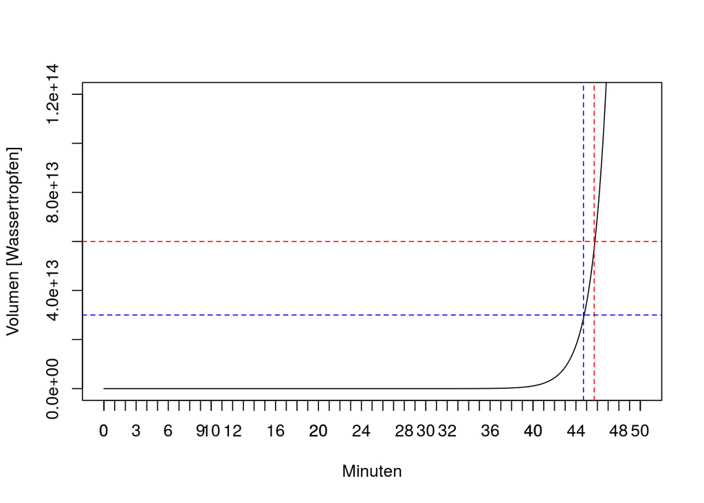

```r
max <- 3e06*20e06 ##Volumen Allianz-Arena
halb <- max/2
max2<-max*2
tmax<-50
t<-seq(0,tmax,by=0.1)
expwachs <- function(t) {y<-1*2^(t/1)}
plot(t,expwachs(t),type="l",ylim=c(0,max2),main="",ylab="Volumen [Wassertropfen]", xlab="Minuten")
axis(side = 1, at = seq(0,tmax,by=1))
abline(h=max,lty=2,col="red")
abline(v=t[458],lty=2,col="red")
abline(h=halb,lty=2,col="blue")
abline(v=t[448],lty=2,col="blue")
```

# 2 Exponentialfunktion

**Jede Exponentialfunktion $a^x$ mit $a>1$ wächst ab einem gewissen $x$ schneller als jede lineare Funktion $a+bx$**.

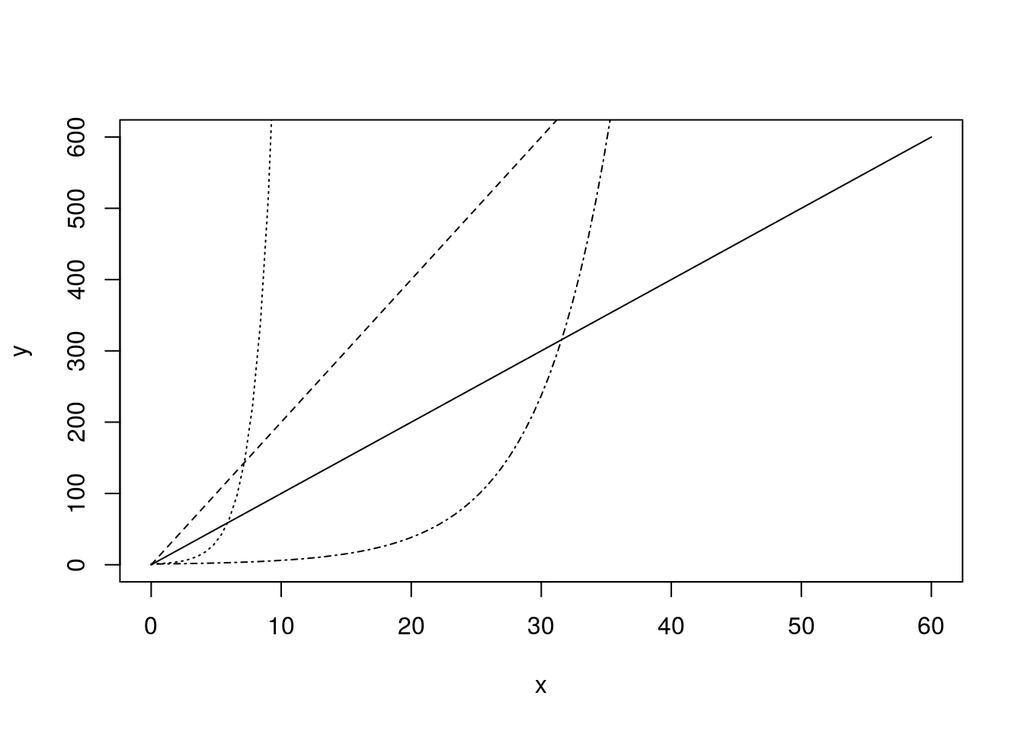

```r
curve(10*x,from=0,to=60,ylab="y")
curve(20*x,add=TRUE,lty=2)
curve(2^x,add=TRUE,lty=3)
curve(1.2^x,add=TRUE,lty=4)
```

# 3 Exponentielles Wachstum

**Exponential growth** is defined by

$$\boxed{x(t)=x_0e^{kt}=x_0e^{t/\tau}=x_02^{t/T}},$$

with $t$: time, $\tau$: $e$-folding time, $T$: doubling time, $k$: growth constant. [^1]

# 4 Daten Covid-19

https://github.com/openZH/covid_19

```r
data<-read.csv("https://raw.githubusercontent.com/openZH/covid_19/master/COVID19_Fallzahlen_CH_total.csv")
names(data)[3]<-"Kanton"
data<-data[,-11]
sKcases<-split(data$ncumul_conf,data$Kanton)
sKfatal<-split(data$ncumul_deceased,data$Kanton)
sKhosp<-split(data$ncumul_hosp,data$Kanton)
sKICU<-split(data$ncumul_ICU,data$Kanton)
sKvent<-split(data$ncumul_vent,data$Kanton)
```

## 4.1 Reported cases

```r
CasesKanton<-sapply(sKcases,function(x){x[max(which(!is.na(x)))]})
CasesKanton
```

```
  AG   AI   AR   BE   BL   BS   FL   FR   GE   GL   GR   JU   LU   NE   NW   OW
1052   25   94 1722  816  936   82 1033 4733  117  802  196  674  669  110   71
  SG   SH   SO   SZ   TG   TI   UR   VD   VS   ZG   ZH
 767   73  382  293  360 3169   80 5143 1830  181 3400
```

```r
sum(CasesKanton)
```

```
[1] 28810
```

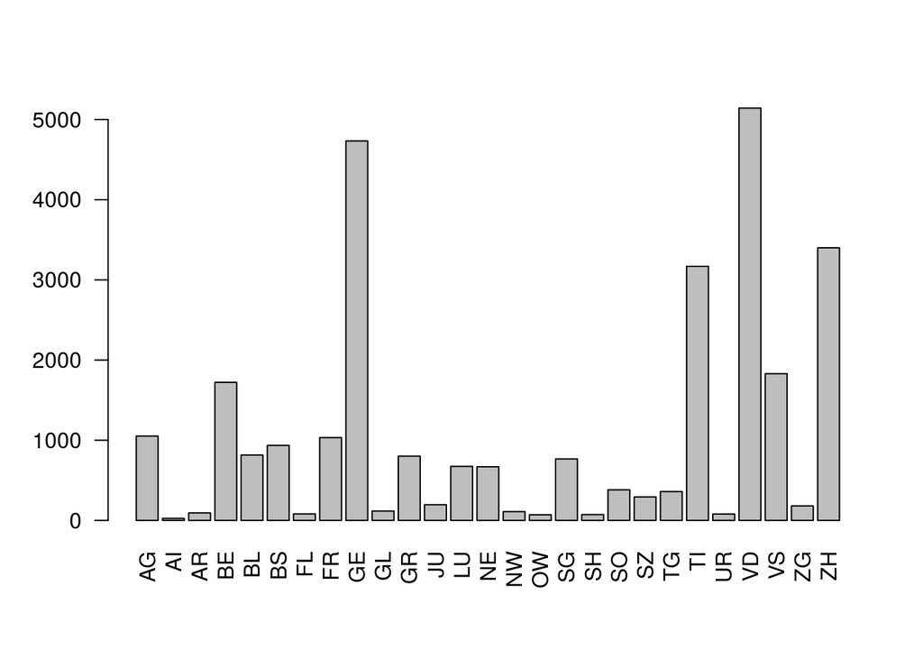

```r
barplot(CasesKanton,las=2)
```

## 4.2 Deceased

```r
FatKanton<-sapply(sKfatal,function(x){x[max(which(!is.na(x)))]})
FatKanton
```

```
 AG  AI  AR  BE  BL  BS  FL  FR  GE  GL  GR  JU  LU  NE  NW  OW  SG  SH  SO  SZ
 31  NA   3  83  30  46   1  77 222   7  43   6  16  64   3   0  31   5  15  18
 TG  TI  UR  VD  VS  ZG  ZH
 16 311   5 331 129   8 115
```

```r
sum(FatKanton,na.rm=TRUE)
```

```
[1] 1616
```

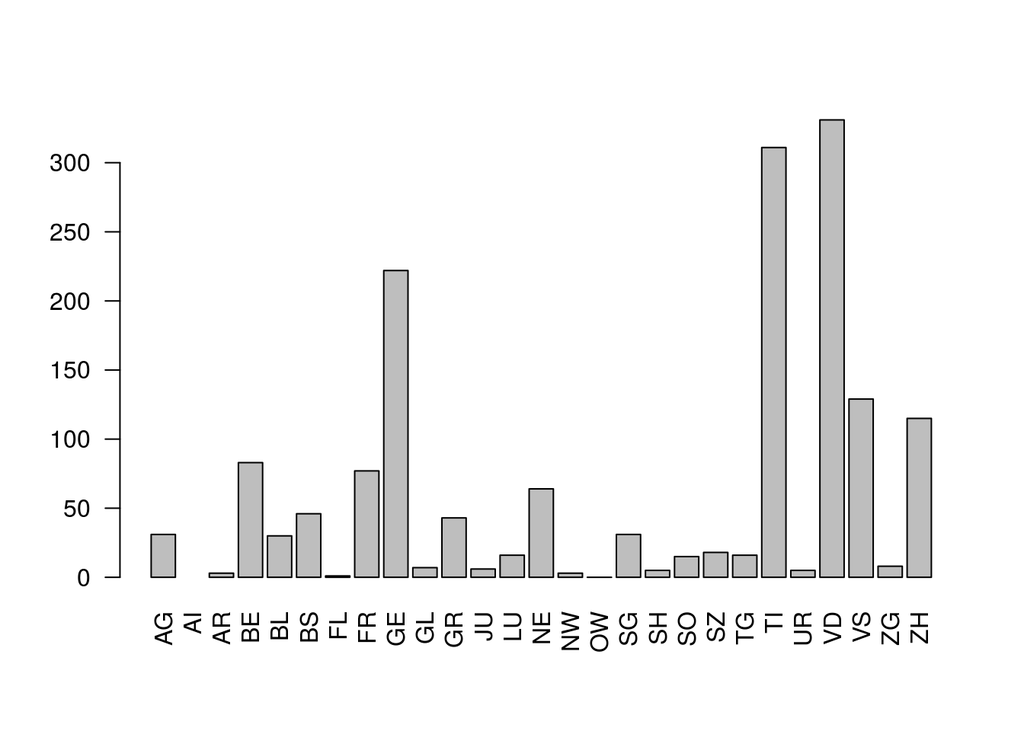

```r
barplot(FatKanton,las=2)
```

## 4.3 Exponentielles Wachstum Covid-19

- Bei Verdoppelung alle 2 Tage: $2^{t/2}=(2^{1/2})^t=1.41^t$
- Bei Verdoppelung alle 3 Tage: $2^{t/3}=(2^{1/3})^t=1.26^t$
- Bei Verdoppelung alle 7 Tage: $2^{t/7}=(2^{1/7})^t=1.1^t$
- Bei Verdoppelung alle 10 Tage: $2^{t/10}=(2^{1/10})^t=1.07^t$

```r
data<-read.csv("https://raw.githubusercontent.com/CSSEGISandData/COVID-19/master/csse_covid_19_data/csse_covid_19_time_series/time_series_covid19_confirmed_global.csv",check.names=FALSE)
sw<-data[data$"Country/Region"=="Switzerland",-c(1,2,3,4)]
cases<-as.numeric(sw[-c(1:42)])
```

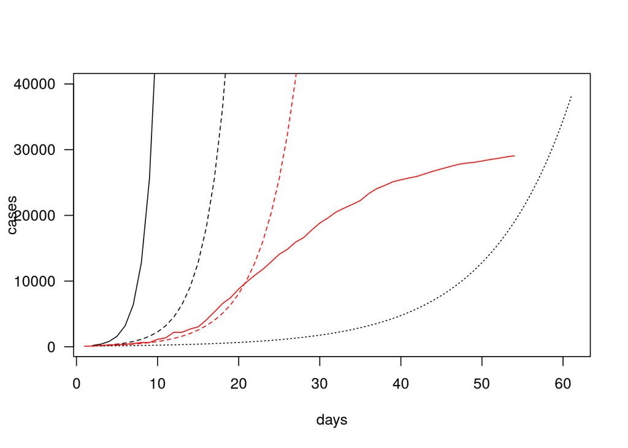

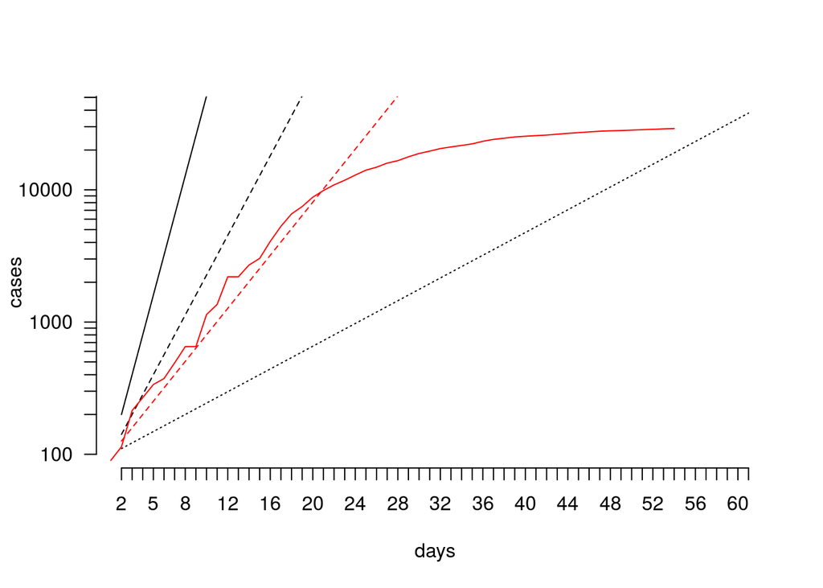

```r
swisspop<-8e6
time<-seq(1,60,by=1)
tag<-1:length(cases)
##################################################
T1<-1
T2<-2
T3<-3
T7<-7
x0<-100
Y1<-x0*2^(time/T1)
Y2<-x0*2^(time/T2)
Y3<-x0*2^(time/T3)
Y7<-x0*2^(time/T7)
time<-time+1

plot(time,Y1,type="l",ylab="cases",ylim=c(100,40000),xlab="days",las=1)
lines(time,Y3,col="red",lty=2)
lines(time,Y2,lty=2)
lines(time,Y7,lty=3)
## abline(h=swisspop,lty=5,col="red")
points(tag,cases,type="l",col="red")

plot(time,Y1,log="y",type="l",ylab="cases",xlab="days",axes=FALSE,ylim=c(100,40000))
at.y <- outer(1:9, 10^(2:9))
lab.y <- ifelse(log10(at.y) %% 1 == 0, at.y, NA)
axis(2, at=at.y, labels=lab.y, las=2)
axis(1,time)
lines(time,Y2,lty=2)
lines(time,Y7,lty=3)
lines(time,Y3,col="red",lty=2)
abline(h=swisspop,col="red",lty=3)
points(tag,cases,type="l",col="red")
```

# 5 Auswirkung Vorfaktor

Annahme: Verdoppelung alle drei Tage, 10 Prozent der Infizierten müssen ins Spital. Die Anzahl Cases von heute sind die Anzahl Spitalpatienten in 9 Tagen, **wenn mann nichts macht**.

$0.1\times 2^{0.33t}=0.1\times (2^{0.33})^t=0.1\times 1.3^t=1.3^{\log_{1.3}0.1}1.3^t=1.3^{t+\log_{1.3}0.1}=1.3^{t-8.776}$

Analog kann man zeigen: Wenn die Mortalitätsrate bei einem Prozent der bestätigten Fälle liegt, dann ist die Anzahl der bestätigten Fälle die zu erwartende Anzahl der Todesfälle ca. 18 Tage später, **wenn man nichts macht**.

$0.01\times 2^{0.33t}=0.01\times (2^{0.33})^t=0.01\times 1.3^t=1.3^{\log_{1.3}0.01}1.3^t=1.3^{t+\log_{1.3}0.01}=1.3^{t-17.552}$

```r
delay<-log(0.1)/log(1.3)
delay
```

```
[1] -8.7763
```

```r
delay2<-log(0.01)/log(1.3)
delay2
```

```
[1] -17.553
```

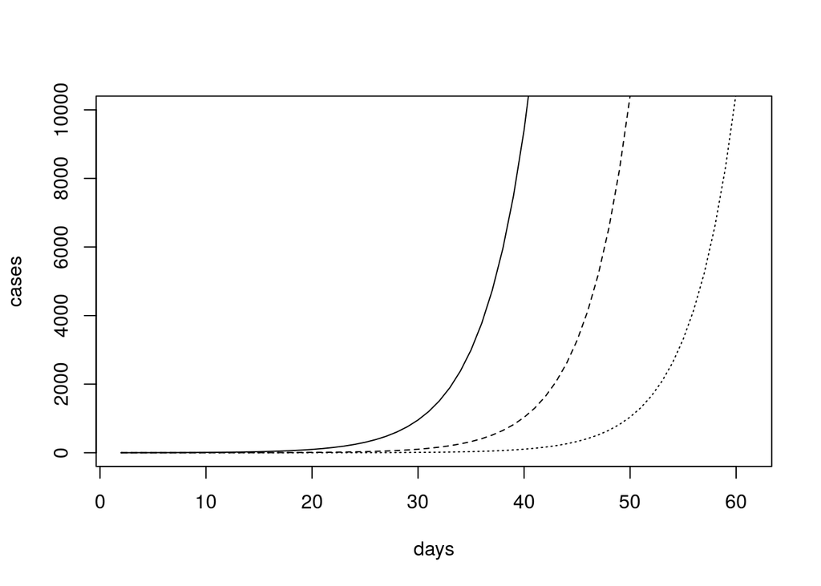

```r
plot(time,2^(0.33*time),ylab="cases",xlab="days",type="l",ylim=c(0,10000))
lines(time,0.1*2^(time/3),lty=2)
lines(time,0.01*2^(time/3),lty=3)
```

[^1]: Proof:
    $$x(t)=x_0e^{kt}=x_0e^{t/\tau}=x_0 2^{\frac{t}{\tau}\log_2e}=x_02^{\frac{t}{\tau} \frac{1}{\log 2 }}=x_02^{t/T}$$